# SBDE: Differential Expression Analysis on Seven Bridges Platform

Marko Zecevic

2016-09-22

# 1 Differential Gene Expression

Detecting differentially expressed genes across sample groups is among the major goals in the statistical analysis of RNA-seq data. Typically, a workflow for this type of analysis would consists of:

- sequence read alignment
- gene expression quantification
- expression normalization
- testing for differential gene expression (DGE)

There is a number of tools developed for this purpose and some are already wrapped and made available on Seven Bridges platforms. There is no general concensus on which tools to use and multiple studies evaluating the performances of different workflows have been published. The choice of aligner will also slightly influence the results of differentially expressed gene detection and gene expression estimation.

`SBDE` package is a collection of API functions bundled together to simplify differential expression analysis on Seven Bridges platforms. It abstracts over the differences in output formats and setting up and running different workflows, allowing an inexperienced platform user to perform his analysis while getting familiar with the graphical interface. The `DifferentialExpressionAnalysis` container is used to keep track of data, chosen alignment and quantification/DE testing workflows and their corresponding tasks. `SBDE` also extends the functionality of `VennDiagram` package to allow for comparison of up to five different workflow choices.

# 2 SBDE workflow

## 2.1 New analysis

You should first set up some variables with your platform token, project id and the choice of API/platform you are using.

```r
your_token <- "29dd0f0d333e473cbb094e8b1014e0d1"
your_project <- "marko_zecevic/sbde-test"
your_platform <- "https://api.sbgenomics.com/v2"
```

A new object of class `DifferentialExpressionAnalysis` is created with `newDEA()`.

```r
testDEA <- newDEA("Hisat_and_DESeq2", your_token, your_project, your_platform,
                  align_wf = "hisat2", de_wf = "deseq2")
testDEA
```

```
## An object of class "DifferentialExpressionAnalysis"
## Slot "title":
## [1] "Hisat_and_DESeq2"
##
## Slot "project":
## == Project ==
## id : marko_zecevic/sbde-test
## name : SBDE test
## billing_group_id : d8473d69-b921-4e79-88c7-92a149ef6f4a
## type : v2
##
## Slot "reference":
## [1] "Drosophila_melanogaster.BDGP5.70.dna.toplevel.fa"
##
## Slot "annotation":
## [1] "Drosophila_melanogaster.BDGP5.70.gtf"
##
## Slot "sample_reads":
##                    sample_id paired_end
## SRR031714_1.fastq untreated1          1
## SRR031714_2.fastq untreated1          2
## SRR031715_1.fastq untreated2          1
## SRR031715_2.fastq untreated2          2
## SRR031716_1.fastq untreated3          1
## SRR031716_2.fastq untreated3          2
## SRR031717_1.fastq untreated4          1
## SRR031717_2.fastq untreated4          2
## SRR031724_1.fastq   treated1          1
## SRR031724_2.fastq   treated1          2
## SRR031725_1.fastq   treated2          1
## SRR031725_2.fastq   treated2          2
## SRR031726_1.fastq   treated3          1
## SRR031726_2.fastq   treated3          2
## SRR031727_1.fastq   treated4          1
## SRR031727_2.fastq   treated4          2
##
## Slot "alignment_wf":
## [1] "hisat2"
##
## Slot "alignment_task":
## [1] NA
##
## Slot "aligned_reads":
## data frame with 0 columns and 0 rows
##
## Slot "quantification_DE_wf":
## [1] "deseq2"
##
## Slot "quantification_DE_task":
## [1] NA
##
## Slot "analysis_results":
## data frame with 0 columns and 0 rows
```

A properly set up project includes only a single reference fasta file, a single annotation file and sample fastq files. If, however, you have additional fasta/gtf/fastq files in your project - you can manually remove the unwanted ones from the `DifferentialExpressionAnalysis` object by directly accessing the `reference`, `annotation` or `sample_reads` slots.

```r
testDEA@sample_reads
```

```
##                    sample_id paired_end
## SRR031714_1.fastq untreated1          1
## SRR031714_2.fastq untreated1          2
## SRR031715_1.fastq untreated2          1
## SRR031715_2.fastq untreated2          2
## SRR031716_1.fastq untreated3          1
## SRR031716_2.fastq untreated3          2
## SRR031717_1.fastq untreated4          1
## SRR031717_2.fastq untreated4          2
## SRR031724_1.fastq   treated1          1
## SRR031724_2.fastq   treated1          2
## SRR031725_1.fastq   treated2          1
## SRR031725_2.fastq   treated2          2
## SRR031726_1.fastq   treated3          1
## SRR031726_2.fastq   treated3          2
## SRR031727_1.fastq   treated4          1
## SRR031727_2.fastq   treated4          2
```

## 2.2 Alignment

Next step is the alignment of sequenced reads. You can create the alignment tasks with `align()`.

```r
testDEA <- align(testDEA, should_run = TRUE)
```

The `alignment_task` slot is no longer NA. It holds the id of the task (batch task if there are multiple samples, and since this is a DE analysis - there should be!) in which the reads are aligned to the reference. If `should_run = FALSE` - draft tasks will be created.

```r
testDEA@alignment_task
```

```
## [1] "60d9459c-9271-480f-a4e4-70e4adc42b3b"
```

You can check the status of running alignment tasks by typing `status(testDEA)` or simply monitor the progress in the visual interface.

## 2.3 Quantification and DGE testing

```r
testDEA@aligned_reads <- list_bam(testDEA)
testDEA@aligned_reads
```

```
##                                    bam_names
## 1 SRR031725_1.HISAT-2.0.1.aligned.sorted.bam
## 2 SRR031724_1.HISAT-2.0.1.aligned.sorted.bam
## 3 SRR031717_2.HISAT-2.0.1.aligned.sorted.bam
## 4 SRR031714_2.HISAT-2.0.1.aligned.sorted.bam
## 5 SRR031727_2.HISAT-2.0.1.aligned.sorted.bam
## 6 SRR031715_2.HISAT-2.0.1.aligned.sorted.bam
## 7 SRR031716_2.HISAT-2.0.1.aligned.sorted.bam
## 8 SRR031726_1.HISAT-2.0.1.aligned.sorted.bam
```

Each sample needs to be associated to a condition. Remember, our goal is to find any differentialy expressed genes between two or more groups.

```r
testDEA@aligned_reads$condition <- c("untreated", "untreated", "treated", "treated",
                                     "untreated", "treated", "treated", "untreated")
testDEA@aligned_reads
```

```
##                                    bam_names condition
## 1 SRR031725_1.HISAT-2.0.1.aligned.sorted.bam untreated
## 2 SRR031724_1.HISAT-2.0.1.aligned.sorted.bam untreated
## 3 SRR031717_2.HISAT-2.0.1.aligned.sorted.bam   treated
## 4 SRR031714_2.HISAT-2.0.1.aligned.sorted.bam   treated
## 5 SRR031727_2.HISAT-2.0.1.aligned.sorted.bam untreated
## 6 SRR031715_2.HISAT-2.0.1.aligned.sorted.bam   treated
## 7 SRR031716_2.HISAT-2.0.1.aligned.sorted.bam   treated
## 8 SRR031726_1.HISAT-2.0.1.aligned.sorted.bam untreated
```

After this sample metadata has been set, we can analyze for DE. Again, this will create and run a task:

```r
testDEA <- analyzeForDE(testDEA, should_run = TRUE)
```

Once the task is completed, we read the analysis results with `readResults()`.

```r
testDEA <- readResults(testDEA)
head(testDEA@analysis_results)
```

```
##                q_value
## FBgn0000003 0.95209909
## FBgn0000008 0.81820500
## FBgn0000014         NA
## FBgn0000015 0.26145723
## FBgn0000017 0.07468119
## FBgn0000018 0.98960838
```

# 3 Exploratory Analysis

Lets say we ran all 6 possible combinations of currently available workflows for alignment and DE testing.

```r
analyses <- c(DEA1, DEA2, DEA3, DEA4, DEA5, DEA6)
sapply(analyses, function (x) x@title)
```

```
## [1] "Tophat_and_cuffdiff" "Tophat_and_DESeq2"   "Star_and_cuffdiff"
## [4] "Star_and_DESeq2"     "Hisat_and_cuffdiff"  "Hisat_and_DESeq2"
```

With `barChart()` we plot the total number of detected differenialy expressed genes for each analysis.

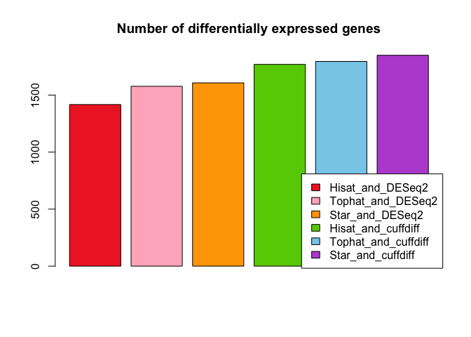

```r
barChart(analyses, alpha = 0.05, fill = c("skyblue", "pink1", "mediumorchid", "orange",
                                          "chartreuse3", "firebrick2"))
```

We can plot Venn diagrams of up to 5 sets but for the sake of interpretability we should probably limit ourselves to 4. Since we have 6 analyses, one of the things we could do is find a pair that is most similar and exclude one of them from the plot.

```r
clusterDendogram(analyses, alpha = 0.05)
```

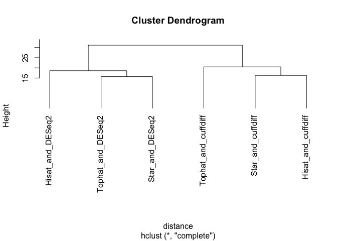

First, we will exclude DEA4 to be able to plot the diagram:

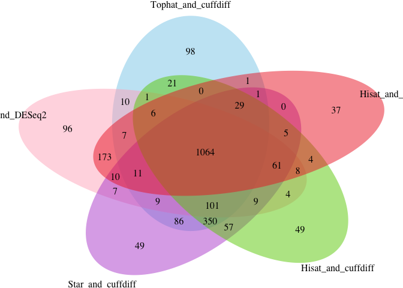

```r
plotVenn(analyses[-4], 0.05, lty = "blank", fill = c("skyblue", "pink1", "mediumorchid",
                                                     "chartreuse3", "firebrick2"))
```

…then both DEA3 and DEA4:

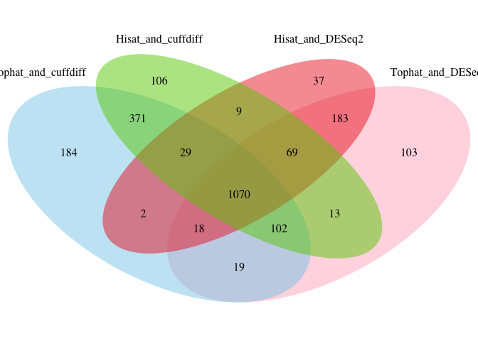

```r
plotVenn(analyses[c(-3,-4)], 0.05, lty = "blank", fill = c("skyblue", "pink1",
                                                           "chartreuse3", "firebrick2"))
```